# chapter5

Aino Peura

These are week 4 excercises.

```r
#Libraries used for this code
library(GGally)
library("factoextra")
library(readr)
library("FactoMineR")
library("tidyverse")
human4 <- read_csv("human.csv")
human4<- as.data.frame(human4)
colnames(human4)[1]<- "Country"
```

In these excercises we will be using the human-data that is from UN website. Our data has 8 columns and 155 countries as rows. Variables as columns are following:

-“Edu2.FM” = population qith at least some secondary education.  
-“Labo.FM” = labor force participation rate (15years and older).  
-“Edu.Exp” = expected education  
-“Life.Exp” = Life expectancy  
-“GNI” = Gender inequality index  
-“Mat.Mor” = maternal mortality ratio  
-“Ado.Birth” =Adolescent birt rate  
-“Parli.F” =Share of sheats in parlament held by woman.

## Lets explore the distributions and relationships of the variables

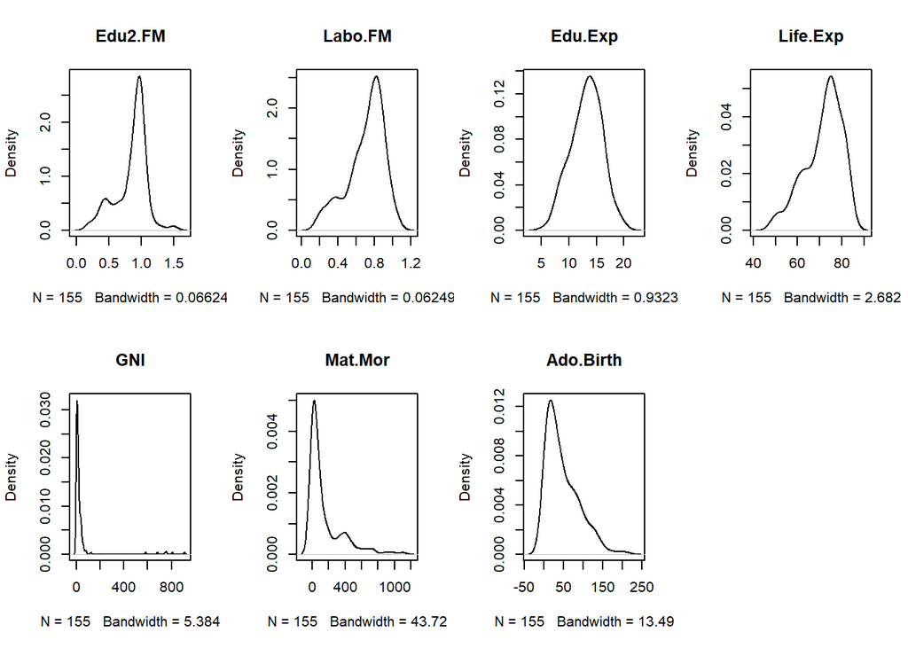

```r
#First, lets plot the graphical overview.
par(mfrow=c(2,4))
for(i in 2:8){
  human4[,i]<- as.numeric(as.character(human4[,i]))
  nimi<- colnames(human4)[i]
  data<- density(human4[,i])
  plot(data, main = nimi)
}
```

Then, lets see the summaries:

```r
summary(human4)
```

```
##    Country             Edu2.FM          Labo.FM          Edu.Exp
##  Length:155         Min.   :0.1717   Min.   :0.1857   Min.   : 5.40
##  Class :character   1st Qu.:0.7264   1st Qu.:0.5984   1st Qu.:11.25
##  Mode  :character   Median :0.9375   Median :0.7535   Median :13.50
##                     Mean   :0.8529   Mean   :0.7074   Mean   :13.18
##                     3rd Qu.:0.9968   3rd Qu.:0.8535   3rd Qu.:15.20
##                     Max.   :1.4967   Max.   :1.0380   Max.   :20.20
##     Life.Exp          GNI             Mat.Mor         Ado.Birth
##  Min.   :49.00   Min.   :  1.123   Min.   :   1.0   Min.   :  0.60
##  1st Qu.:66.30   1st Qu.:  5.275   1st Qu.:  11.5   1st Qu.: 12.65
##  Median :74.20   Median : 13.054   Median :  49.0   Median : 33.60
##  Mean   :71.65   Mean   : 46.496   Mean   : 149.1   Mean   : 47.16
##  3rd Qu.:77.25   3rd Qu.: 27.256   3rd Qu.: 190.0   3rd Qu.: 71.95
##  Max.   :83.50   Max.   :908.000   Max.   :1100.0   Max.   :204.80
##     Parli.F
##  Min.   : 0.00
##  1st Qu.:12.40
##  Median :19.30
##  Mean   :20.91
##  3rd Qu.:27.95
##  Max.   :57.50
```

Then, lets look at the relationships between variables:

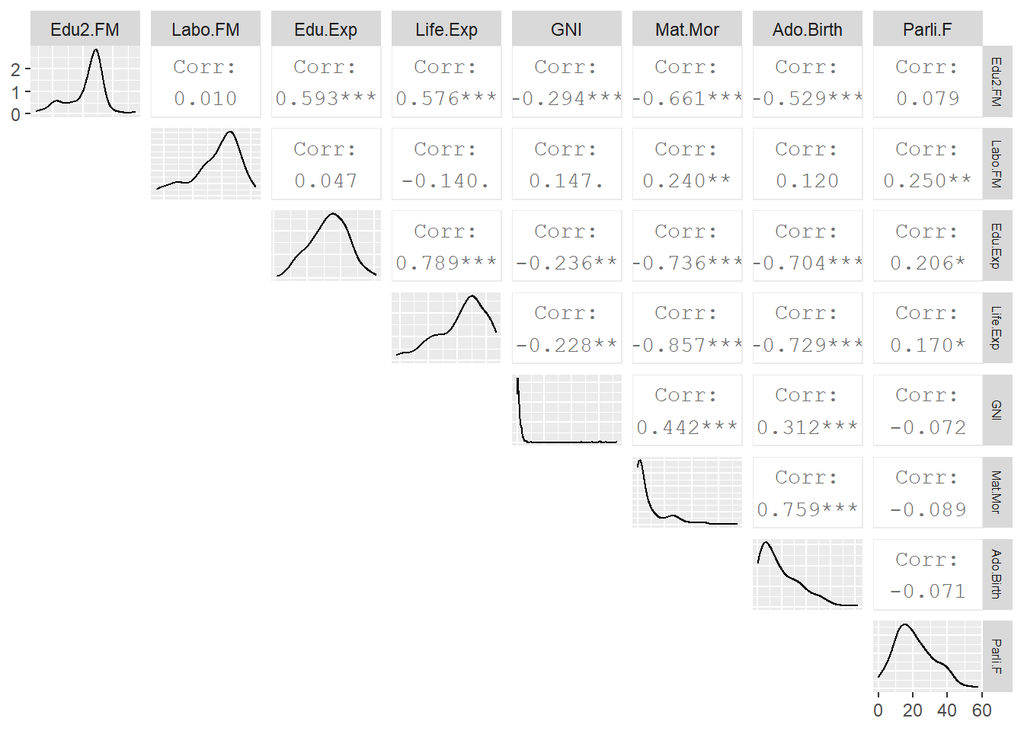

```r
human5<- human4[,2:9]
ggpairs(human5, lower = "blank")+
  theme(strip.text.y = element_text(size=6))
```

## Excercise 2, the PCA

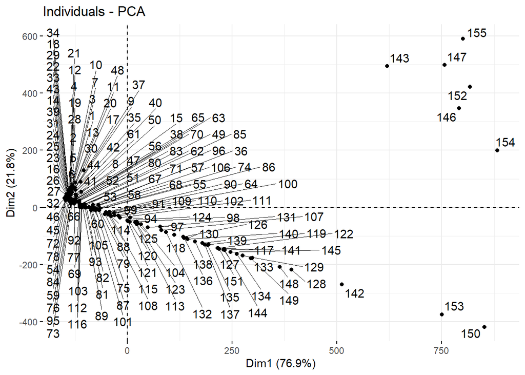

```r
pca<- prcomp(human5)
par(mfrow = c(1, 2))
fviz_pca_ind(pca, geom= c("point", "text"), repel = T, addEllipses = F)
```

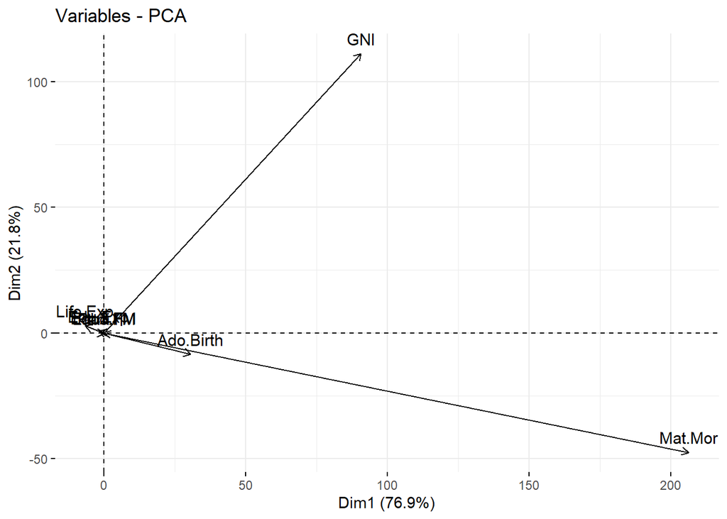

```r
fviz_pca_var(pca)
```

I did not do a biplot, because with 155 observations it just looks like a mess. However, here we can see. that PCA1 represents 76.9% of the variation, while our dimension 2 has 21.8% of the variation. The greatest sources of variatiob are maternal mortality and GNi, also adolescent birth rate is creating some variation.

## Lets do the same for scaled variables

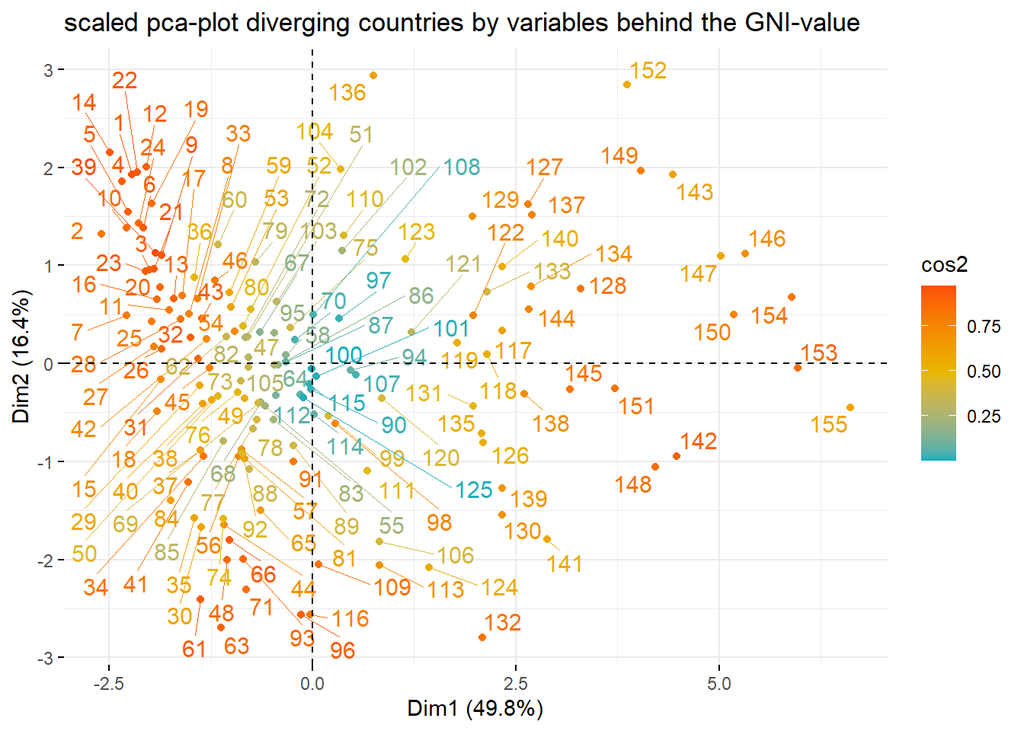

```r
human6<- scale(human5)

pca<- prcomp(human6)
par(mfrow = c(1, 2))
fviz_pca_ind(pca, geom= c("point", "text"), repel = T, addEllipses = F, col.ind = "cos2", gradient.cols = c("#00AFBB", "#E7B800", "#FC4E07"))+
  ggtitle("scaled pca-plot diverging countries by variables behind the GNI-value")
```

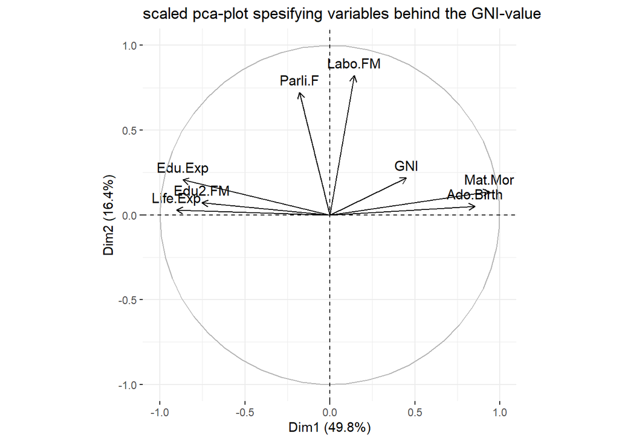

```r
fviz_pca_var(pca)+
  ggtitle("scaled pca-plot spesifying variables behind the GNI-value")
```

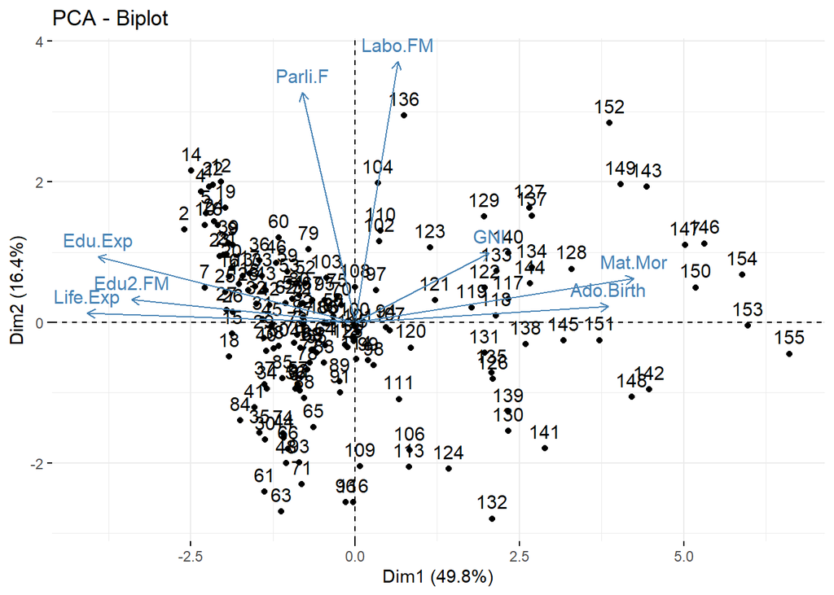

```r
fviz_pca_biplot(pca)
```

Well, now the results differ quite a lot. Here we can see, that in pca1: expected education, amount of women with secondary education, life expectancy and on the other side GNI, maternal mortality and adolescent birt rate are making the differnece, In the second principal component, amount of women in parlament and amount of women in labor force are crating the greatest difference. These results differ more (there are more variables making a significant difference, because variation of the variables is scaled and thus more equal). The range of the values in human 4 (unscaled data frame) is greatest with maternal mortaluty, gni and adolescent birt rate. By the way, the colors represent how well each point is separated (more red, further)

```r
summary(human5)
```

```
##     Edu2.FM          Labo.FM          Edu.Exp         Life.Exp
##  Min.   :0.1717   Min.   :0.1857   Min.   : 5.40   Min.   :49.00
##  1st Qu.:0.7264   1st Qu.:0.5984   1st Qu.:11.25   1st Qu.:66.30
##  Median :0.9375   Median :0.7535   Median :13.50   Median :74.20
##  Mean   :0.8529   Mean   :0.7074   Mean   :13.18   Mean   :71.65
##  3rd Qu.:0.9968   3rd Qu.:0.8535   3rd Qu.:15.20   3rd Qu.:77.25
##  Max.   :1.4967   Max.   :1.0380   Max.   :20.20   Max.   :83.50
##       GNI             Mat.Mor         Ado.Birth         Parli.F
##  Min.   :  1.123   Min.   :   1.0   Min.   :  0.60   Min.   : 0.00
##  1st Qu.:  5.275   1st Qu.:  11.5   1st Qu.: 12.65   1st Qu.:12.40
##  Median : 13.054   Median :  49.0   Median : 33.60   Median :19.30
##  Mean   : 46.496   Mean   : 149.1   Mean   : 47.16   Mean   :20.91
##  3rd Qu.: 27.256   3rd Qu.: 190.0   3rd Qu.: 71.95   3rd Qu.:27.95
##  Max.   :908.000   Max.   :1100.0   Max.   :204.80   Max.   :57.50
```

```r
summary(human6)
```

```
##     Edu2.FM           Labo.FM           Edu.Exp           Life.Exp
##  Min.   :-2.8189   Min.   :-2.6247   Min.   :-2.7378   Min.   :-2.7188
##  1st Qu.:-0.5233   1st Qu.:-0.5484   1st Qu.:-0.6782   1st Qu.:-0.6425
##  Median : 0.3503   Median : 0.2316   Median : 0.1140   Median : 0.3056
##  Mean   : 0.0000   Mean   : 0.0000   Mean   : 0.0000   Mean   : 0.0000
##  3rd Qu.: 0.5958   3rd Qu.: 0.7350   3rd Qu.: 0.7126   3rd Qu.: 0.6717
##  Max.   : 2.6646   Max.   : 1.6632   Max.   : 2.4730   Max.   : 1.4218
##       GNI             Mat.Mor          Ado.Birth          Parli.F
##  Min.   :-0.3162   Min.   :-0.6992   Min.   :-1.1325   Min.   :-1.8203
##  1st Qu.:-0.2873   1st Qu.:-0.6496   1st Qu.:-0.8394   1st Qu.:-0.7409
##  Median :-0.2330   Median :-0.4726   Median :-0.3298   Median :-0.1403
##  Mean   : 0.0000   Mean   : 0.0000   Mean   : 0.0000   Mean   : 0.0000
##  3rd Qu.:-0.1341   3rd Qu.: 0.1932   3rd Qu.: 0.6030   3rd Qu.: 0.6127
##  Max.   : 6.0037   Max.   : 4.4899   Max.   : 3.8344   Max.   : 3.1850
```

## Give your personal interpretations of the first two principal component dimensions based on the biplot drawn after PCA on the standardized human data. (0-2 points)

Lets observe the variations inside each principal component. First, lets see how pca’s are divided.

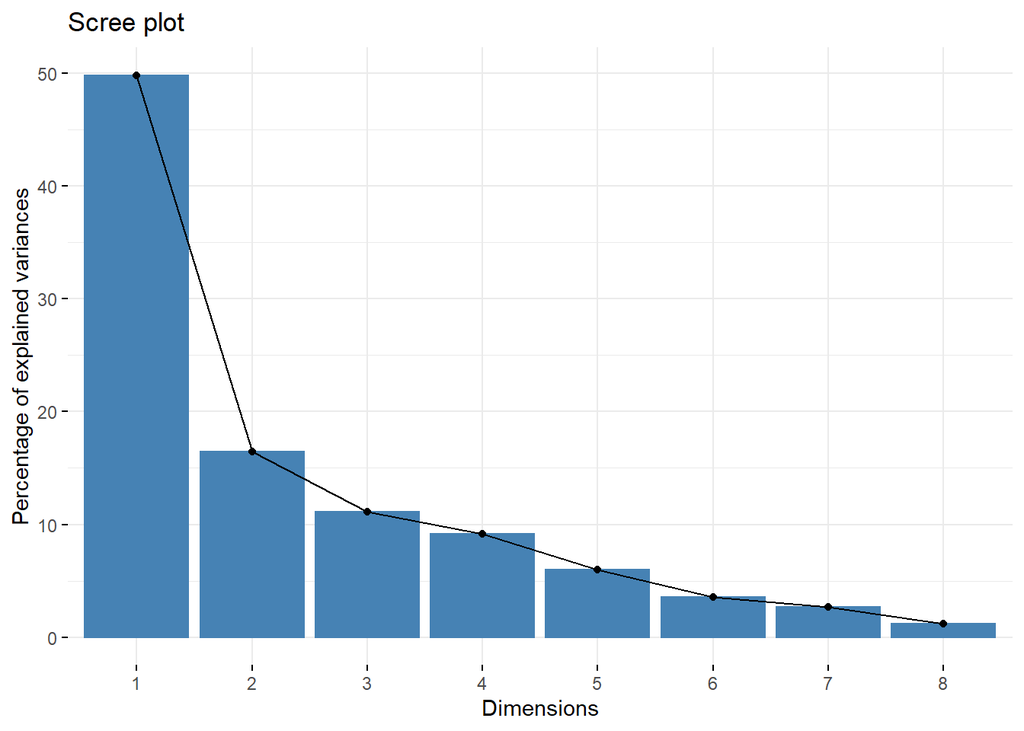

```r
fviz_eig(pca)
```

From the graph above, we can observe that 49.8% of the variation is explained with PCa1, and 16.4% with pca2.

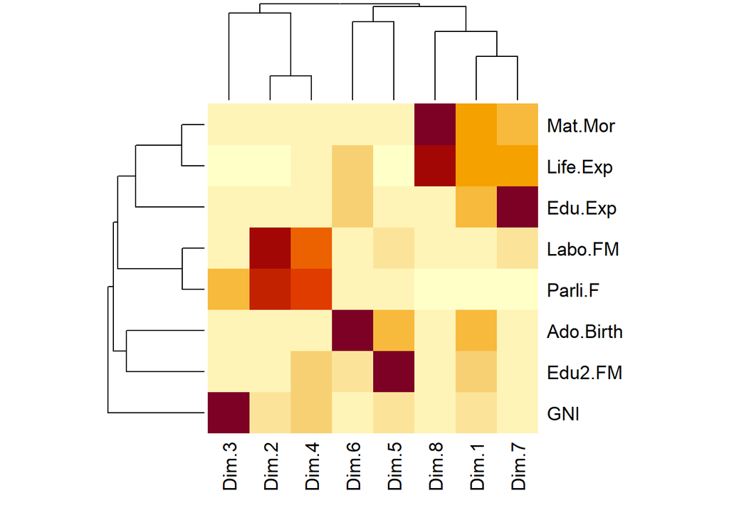

```r
res.var <- get_pca_var(pca)
heatmap(res.var$contrib )
```

From the heatmap below, we can see that for the pca1, variables maternal mortality, life expectancy, education expectancy and adolescent birth are contributing quite much for the total variabce. For the second principal component, we can see that labor.FM and parli.F are contributing quite much, while the rest of the variables are contributing less, This heatmap also gives us some interesting thoughts, because we can see that after certain point, our pca-components start to be very similar to each other, or just separation based on one variable.

## Load the tea dataset from the package Factominer. Explore the data briefly: look at the structure and the dimensions of the data and visualize it. Then do Multiple Correspondence Analysis on the tea data (or to a certain columns of the data, it’s up to you). Interpret the results of the MCA and draw at least the variable biplot of the analysis. You can also explore other plotting options for MCA. Comment on the output of the plots

Lets load the dataset and observe the dimensions, structures etc.

```r
data(tea)
str(tea)
```

```
## 'data.frame':    300 obs. of  36 variables:
##  $ breakfast       : Factor w/ 2 levels "breakfast","Not.breakfast": 1 1 2 2 1 2 1 2 1 1 ...
##  $ tea.time        : Factor w/ 2 levels "Not.tea time",..: 1 1 2 1 1 1 2 2 2 1 ...
##  $ evening         : Factor w/ 2 levels "evening","Not.evening": 2 2 1 2 1 2 2 1 2 1 ...
##  $ lunch           : Factor w/ 2 levels "lunch","Not.lunch": 2 2 2 2 2 2 2 2 2 2 ...
##  $ dinner          : Factor w/ 2 levels "dinner","Not.dinner": 2 2 1 1 2 1 2 2 2 2 ...
##  $ always          : Factor w/ 2 levels "always","Not.always": 2 2 2 2 1 2 2 2 2 2 ...
##  $ home            : Factor w/ 2 levels "home","Not.home": 1 1 1 1 1 1 1 1 1 1 ...
##  $ work            : Factor w/ 2 levels "Not.work","work": 1 1 2 1 1 1 1 1 1 1 ...
##  $ tearoom         : Factor w/ 2 levels "Not.tearoom",..: 1 1 1 1 1 1 1 1 1 2 ...
##  $ friends         : Factor w/ 2 levels "friends","Not.friends": 2 2 1 2 2 2 1 2 2 2 ...
##  $ resto           : Factor w/ 2 levels "Not.resto","resto": 1 1 2 1 1 1 1 1 1 1 ...
##  $ pub             : Factor w/ 2 levels "Not.pub","pub": 1 1 1 1 1 1 1 1 1 1 ...
##  $ Tea             : Factor w/ 3 levels "black","Earl Grey",..: 1 1 2 2 2 2 2 1 2 1 ...
##  $ How             : Factor w/ 4 levels "alone","lemon",..: 1 3 1 1 1 1 1 3 3 1 ...
```

[output cut: 22 more lines]

```r
#The data has 300 obs. of  36 variables.

par(mfrow=c(6,6))
for(i in 1:36){
  nimi<- colnames(tea)[i]
  data<- as.data.frame(tea[,i])
  colnames(data)<- "column"
  data$nimi<-nimi
  if(i==1){
    data2<-data
  }else{
    data2<- rbind.data.frame(data2, data)
  }
}
```

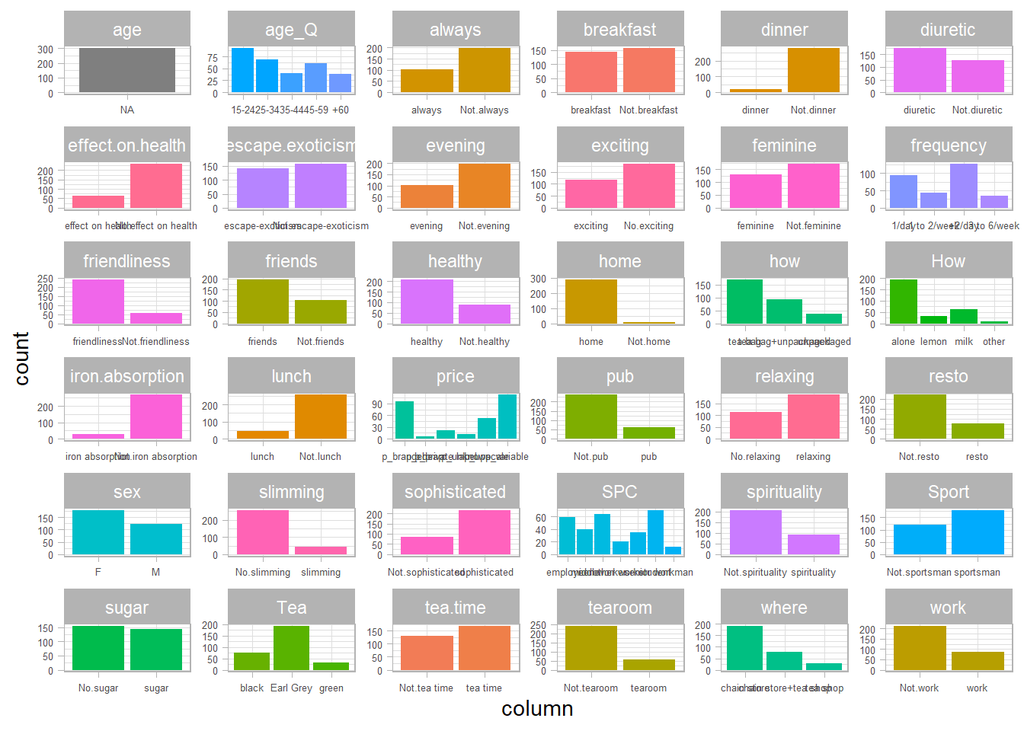

```r
 ggplot(data2, aes(column, fill=column))+
    geom_bar()+
    theme_light()+
   facet_wrap(vars(nimi),  scales= "free", shrink = T)+
   theme(legend.position = "none", axis.text.x = element_text(size=5),
         axis.text.y = element_text(size=5))
```

Then, lets look structure and dimensions of the data:

```r
str(tea)
```

```
## 'data.frame':    300 obs. of  36 variables:
##  $ breakfast       : Factor w/ 2 levels "breakfast","Not.breakfast": 1 1 2 2 1 2 1 2 1 1 ...
##  $ tea.time        : Factor w/ 2 levels "Not.tea time",..: 1 1 2 1 1 1 2 2 2 1 ...
##  $ evening         : Factor w/ 2 levels "evening","Not.evening": 2 2 1 2 1 2 2 1 2 1 ...
##  $ lunch           : Factor w/ 2 levels "lunch","Not.lunch": 2 2 2 2 2 2 2 2 2 2 ...
##  $ dinner          : Factor w/ 2 levels "dinner","Not.dinner": 2 2 1 1 2 1 2 2 2 2 ...
##  $ always          : Factor w/ 2 levels "always","Not.always": 2 2 2 2 1 2 2 2 2 2 ...
##  $ home            : Factor w/ 2 levels "home","Not.home": 1 1 1 1 1 1 1 1 1 1 ...
##  $ work            : Factor w/ 2 levels "Not.work","work": 1 1 2 1 1 1 1 1 1 1 ...
##  $ tearoom         : Factor w/ 2 levels "Not.tearoom",..: 1 1 1 1 1 1 1 1 1 2 ...
##  $ friends         : Factor w/ 2 levels "friends","Not.friends": 2 2 1 2 2 2 1 2 2 2 ...
##  $ resto           : Factor w/ 2 levels "Not.resto","resto": 1 1 2 1 1 1 1 1 1 1 ...
##  $ pub             : Factor w/ 2 levels "Not.pub","pub": 1 1 1 1 1 1 1 1 1 1 ...
##  $ Tea             : Factor w/ 3 levels "black","Earl Grey",..: 1 1 2 2 2 2 2 1 2 1 ...
##  $ How             : Factor w/ 4 levels "alone","lemon",..: 1 3 1 1 1 1 1 3 3 1 ...
```

[output cut: 22 more lines]

```r
dim(tea)
```

```
## [1] 300  36
```

Then, lets do Multiple Correspondence Analysis for all of our variables.

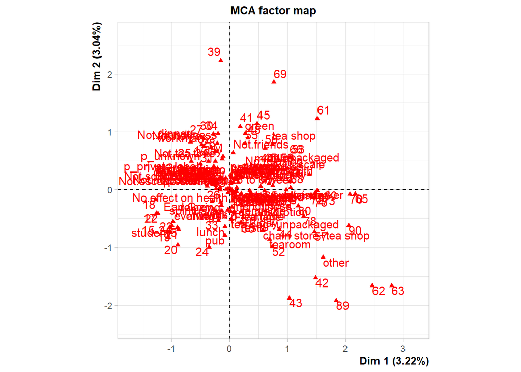

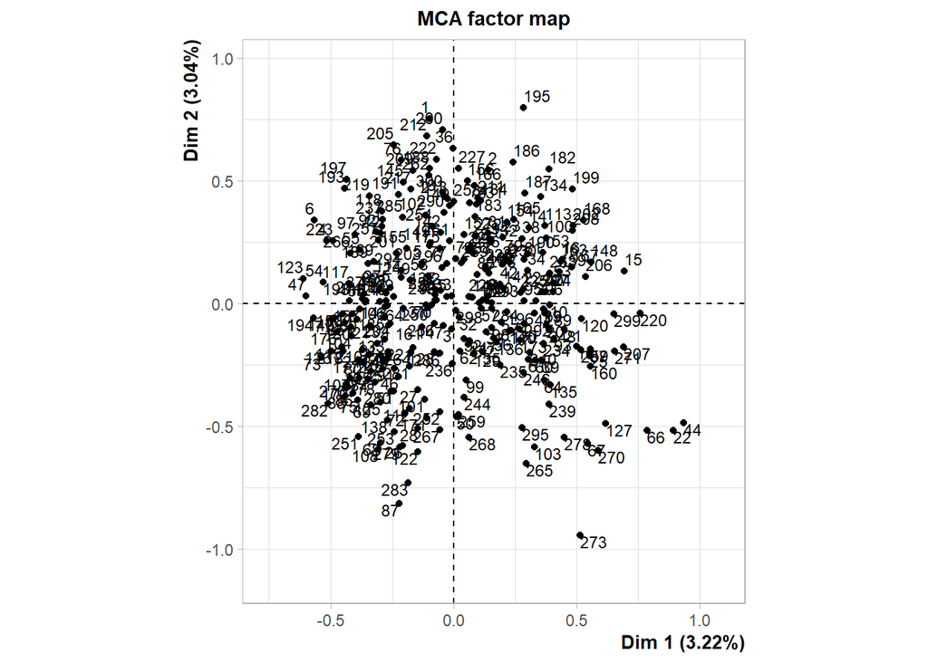

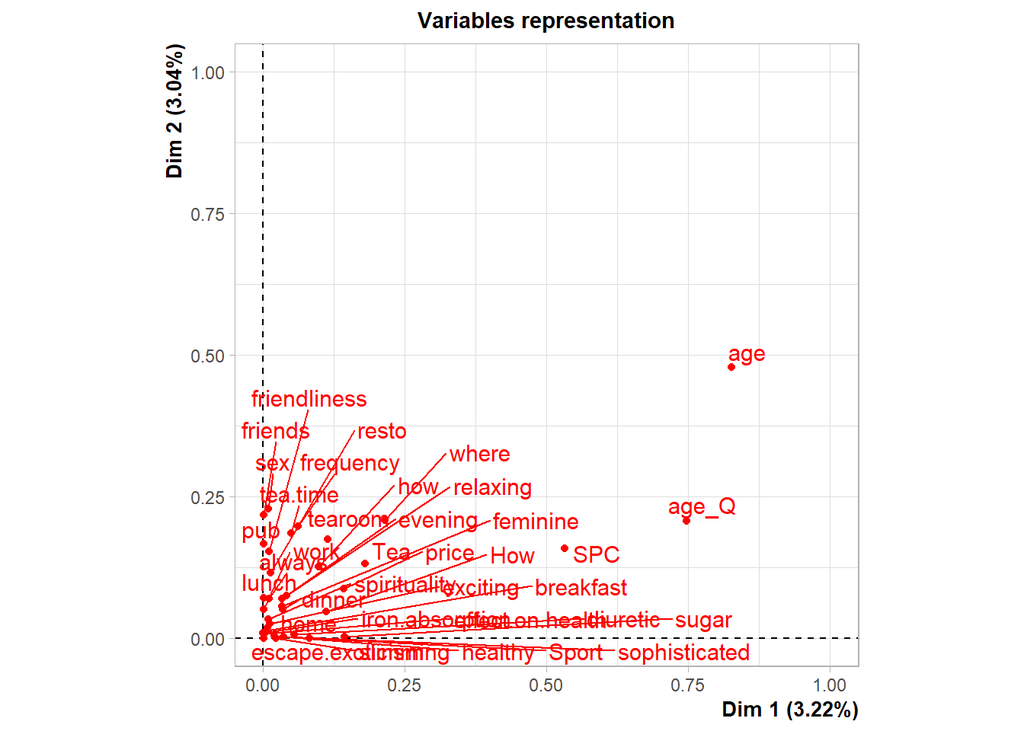

```r
#Lets first transform all variables to factors, without this we will only have some errors
tea2 <- tea %>% mutate_all(as.factor)
#Then, lets do MCA
Multi<- MCA(tea2, graph = T)
```

From the MCA-plot, we can conclude following: Age, age-q (catecorigal age) and SPC are the variables that are responsible for the most of the variation along x-axis. They were also the variables with most categories, I wonder if this is because of that.

Sex, friends, where, tea and pub are, also in addition to the variables already mentioned leading to that point.